# Programming with ggplot2

2016-10-7 20:25

Look at the subset of the `diamonds` dataset below.

```r
library("tidyverse")
source("multiplot.R") # http://www.cookbook-r.com/Graphs/Multiple_graphs_on_one_page_(ggplot2)/
```

```r
dta <- select(diamonds, price, cut, carat, color)
```

Now, imagine you want a quick summary for each variable. Unfortunately, the variabels are not all of the same class. For the factors, you could do a bar chart, for the integers, you might wan to use a density plot. You could do the following for cut and color.

```r
p1 <- ggplot(dta, aes(cut)) + geom_bar()
p2 <- ggplot(dta, aes(color)) + geom_bar()
```

Similarly, you can do for price and carat

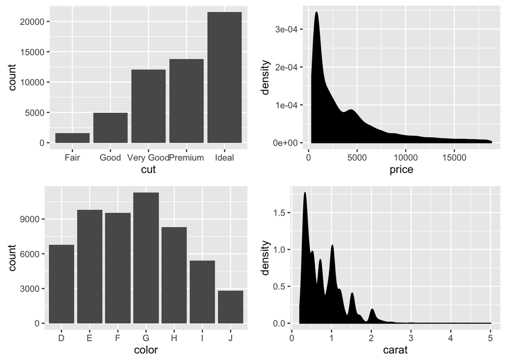

```r
p3 <- ggplot(dta, aes(price)) + geom_density(color = "black", fill = "black")
p4 <- ggplot(dta, aes(carat)) + geom_density(color = "black", fill = "black")

multiplot(p1, p2, p3, p4, cols = 2)
```

Now, you can note two things

- you have a lot of code duplication
- you need to futher customize the second graph with a transformation to make the visualization more intersting.

To address the first problem, part of the answer is creating a function that behaves differently depending on whether the input is factorial or numeric.

```r
# a function that returns geom_hist if the input is numberic,
# geom_bar otherwise
geom_hist_or_bar <- function() {
  if(current_class() %in% c("integer", "numeric")) {
  geom_density(color = "black", fill = "black")
  } else {
  geom_bar()
  }
}
```

`current_class` is a function that magically gets the class of the variable that you used in `aes` of `ggplot`. Similarly, we can define a function `scale_x_adapt` that returns a transformed scale if the input is numerical (using the `current_class` function again.) Having defined that function, you could rewrite the above as follows.

```r
ggplot(dta, aes(color)) + geom_hist_or_bar()
ggplot(dta, aes(cut))   + geom_hist_or_bar()
ggplot(dta, aes(price))  + geom_hist_or_bar()
ggplot(dta, aes(carat))   + geom_hist_or_bar()
```

This is a slight improvement to the first solution, because you always call the same functions for all plots. Hence, we can kind of use an `apply` approach to reduce the redundancy of this problem. You might think of the following

```r
lapply(dta, function(g) ggplot(dta, aes(g)) + geom_hist_or_bar)
```

Unfortunately, this does not quite work, because `x` will be the actual values from each column, but in `aes`, you need the name of the column, not the actual value. Since there is no way to get from the values to the names, but if we have the names, we can get the values, the trick is to loop over the names of the data frame. In this case, we need to wrap the names in `as.list`, because names will be a vector, but `lapply` wants to iterate over a list.

```r
lapply(as.list(names(dta)), function(x) ggplot(dta, aes(x)) + geom_hist_or_bar)
```

However, we are not quite there yet. Due to non-standard evaluation, we need to further change two things.

Now, we are done.

```r
lapply(as.list(names(dta)), function(g) { # seems as it needs to be a list!
  ggplot(dta, aes_(as.name(g))) +
    geom_hist_or_bar() +
    scale_x_adapt()
})
```

The only explanation I still owe you is how the function `current_class()` works. It only works because it is called from within `lapply`. Hence, the parent frame of `current_class` is `lapply`. For a given iteration, the value of g is available in the environment of `lapply`. `currrent_class` simply needs to go *up the tree* until it reaches the environment of `lapply` and get the value of g and figure out it’s class. That is done as follows.

```r
current_class <- function() {
  # returns the first class of the current iteration*
  class(dta[[get("g", parent.frame(n = 2))]])[1]
}
# * first element since object can have multiple classes
```

Finally, we can get it running

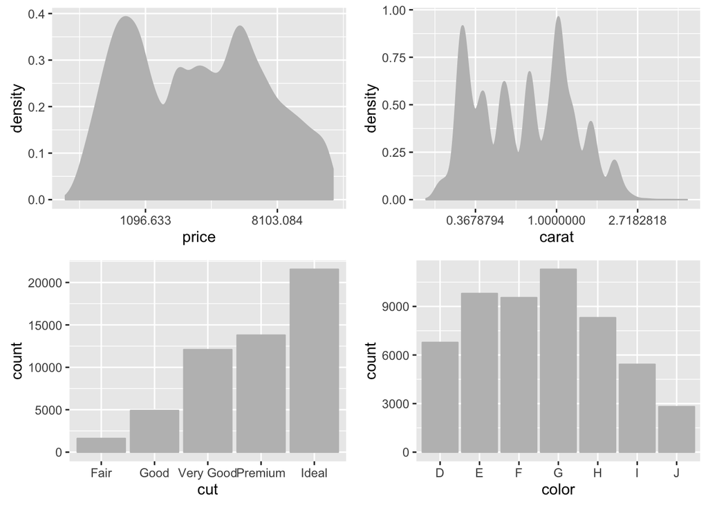

```r
current_class <- function() {
  # returns the first class of the current iteration*
  class(dta[[get("g", parent.frame(n = 2))]])[1]
}
# * first element since object can have multiple classes

geom_hist_or_bar <- function() {
  color <- "gray"
  if(current_class() %in% c("integer", "numeric")) {
  geom_density(color = color, fill = color)
  } else {
  geom_bar(color = color, fill = color)
  }
}

scale_x_adapt <- function() {
  if(current_class() %in% c("integer", "numeric")) {
    scale_x_continuous(trans = "log")
  } else {
    scale_x_discrete()
  }

}

all_plots <- lapply(as.list(names(dta)), function(g) { # seems as it needs to be a list!
  ggplot(dta, aes_(as.name(g))) +
    geom_hist_or_bar() +
    scale_x_adapt()
})

do.call("multiplot", list(plotlist = all_plots, cols = 2)) # use plotlist not ... as input
```